```python
%%capture
from data import *
import yaml
from IPython.display import display, HTML
import seaborn as sns
from scipy.stats import shapiro, wilcoxon, ttest_1samp, ttest_rel, shapiro, skew, kurtosis, norm
import warnings
warnings.filterwarnings("ignore")
```

# An Analysis of Congressional Stock Market Trades Since the STOCK Act

### Kai Barker, Faculty Advisor: Dr. Tomoyuki Ichiba

Members of Congress have long faced scrutiny over their stock trading activities, with recent polling showing over 80% of Americans support a congressional trading ban<sup>[1]</sup>. In 1934 the Securities Exchange Act was passed to limit insider trading, but the rules didn’t apply to Congress<sup>[2]</sup>. The Stop Trading on Congressional Knowledge (STOCK) Act of 2012 attempted to remedy this issue, falling short in practice. The Act mandates that Members disclose trades over 1000 dollars within 45 days and explicitly subjects them to insider trading laws, yet the fine for failing to do so is only 200 dollars<sup>[3]</sup>. Members of Congress have access to confidential information, legislative power, knowledge of government contracts, and connections to other influential people. The legality of their trading raises questions, especially given examples of suspicious behavior. Shortly before the Affordable Care Act passed, Senator John Kerry, Senator Jim Webb, Congressman Vern Buchanan, as well as many other politicians, purchased healthcare stocks, with estimated gains between 15% to 50% in the following six-month period<sup>[2]</sup>. In another case, the Senate Committee on Health’s meeting regarding COVID-19 in January of 2020 led to Senator Dianne Feinstein making significant trades shortly before the market downturn<sup>[2]</sup>. Public trust in Congress remains low, with 7 in 10 Americans holding an unfavorable view<sup>[2]</sup>. While policies have been proposed to ban Members from acquiring new stocks or require full divestment, no legislation has yet passed. Given the opportunity for profit, examples of possible suspicious trading, and low public sentiment, accusations of wrongdoing are common, but are they justified? Prior research suggests Members of Congress earned significant abnormal returns on their trades before the STOCK Act, but not afterward<sup>[4]</sup>. Other studies have found that stock ownership correlates with politicians making decisions favorable to those respective companies, suggesting a mutual interest from Members and corporate stakeholders<sup>[5]</sup>. However, these studies were both published nearly a decade ago and don’t account for new data, especially the over $150 million traded by Congress during the COVID-19 pandemic<sup>[2]</sup>. With 12 years of STOCK Act disclosures now available from 2012 to 2024, this study examines whether U.S. Congressional Members generate abnormal returns on their stock trades, analyzing overall portfolio performance, and whether committee membership generates superior overall returns.

### Data Cleaning and Preprocessing:

For this study, historical time series data was needed for three components. The first component was the Members and their trades, where publicly available data can be collected from disclosures on the official government websites, however the format of the data (PDFs or images of disclosures) made it incredibly difficult to retrieve. Instead an ensemble of three datasets, sourced from Kaggle, provided a comprehensive collection of congressional trades (~70,000 rows). These datasets spanned different ranges between 2012 and 2024, and contained 46,000, 15,000, and 5,000 observations respectively, with many duplicates. However, a limitation with the data sources was the verification of trades with those available on the government websites, as well as differing amounts of information contained, and most notably, naming conventions such as including suffixes or nicknames. The second component was the prices of the stocks themselves, needed for determining profits and losses over holding periods. This data was also sourced from Kaggle as well as the yfinance API. The third component was our benchmark, the S&P 500. This was selected as a baseline due to its historic use as an indication of overall market health, broad scope of sectors, and market capitalization weighting<sup>[6]</sup>. We assume that all the collected data is accurate, and we base our analysis on the closing prices for stocks and the S&P 500.

### Data Analysis:

```python
%%capture
buys = stock_trades[stock_trades['transaction_type'] == 'Purchase'].copy()
sells = stock_trades[stock_trades['transaction_type'].isin(['Sale', 'Sale (Full)', 'Sale (Partial)'])].copy()

matched_trades = []

for member in buys['owner_name'].unique():
    for ticker in buys[buys['owner_name'] == member]['ticker'].unique():
        # Get this member's buys and sells for this ticker
        member_ticker_buys = buys[(buys['owner_name'] == member) & (buys['ticker'] == ticker)].sort_values('transaction_date')
        member_ticker_sells = sells[(sells['owner_name'] == member) & (sells['ticker'] == ticker)].sort_values('transaction_date')

        for _, sell_row in member_ticker_sells.iterrows():
            # Find buys before this sell
            prior_buys = member_ticker_buys[member_ticker_buys['transaction_date'] < sell_row['transaction_date']]

            if len(prior_buys) > 0:
                buy_row = prior_buys.iloc[0]  # FIFO - first buy

                # Calculate return
                profit_pct = ((sell_row['price'] - buy_row['price']) / buy_row['price']) * 100
                holding_days = (sell_row['transaction_date'] - buy_row['transaction_date']).days

                matched_trades.append({
                    'owner_name': member,
                    'ticker': ticker,
                    'buy_date': buy_row['transaction_date'],
                    'sell_date': sell_row['transaction_date'],
                    'buy_price': buy_row['price'],
                    'sell_price': sell_row['price'],
                    'profit_pct': profit_pct,
                    'holding_days': holding_days
                })

returns_df = pd.DataFrame(matched_trades)

print(f"Matched {len(returns_df)} buy-sell pairs")
```

First, we returns from the S&P 500 were calculated over the same time period that the stock trades cover, and the compound annual growth rate was calculated to be 12.49%.

```python
%%capture
sandp_retns = yf.download("^GSPC", start="2012-09-01", end="2024-12-01", interval="1mo")
sp500_start_price = sandp_retns['Close'].iloc[0]
sp500_end_price = sandp_retns['Close'].iloc[-1]
total_return = (sp500_end_price - sp500_start_price) / sp500_start_price

start_date = sandp_retns.index[0]
end_date = sandp_retns.index[-1]
years = (end_date - start_date).days / 365.25
cagr = (1 + total_return) ** (1/years) - 1
```

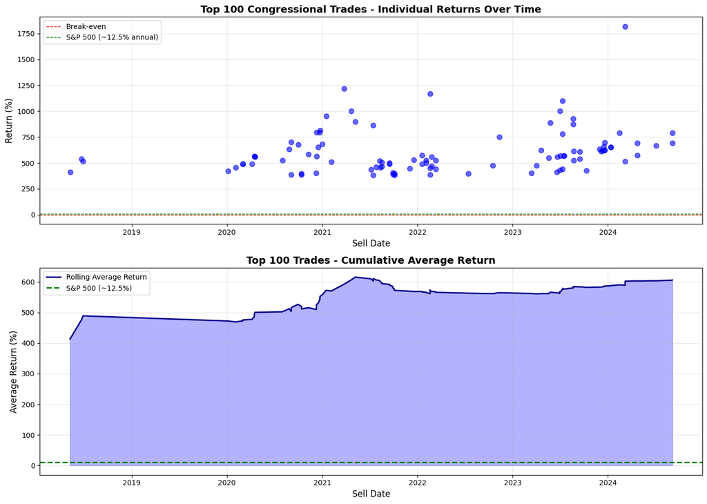

```python
top_100_trades = returns_df.nlargest(100, "profit_pct").copy()
top_100_trades = top_100_trades.sort_values('sell_date')

# Calculate rolling average
top_100_trades['cumulative_avg_return'] = top_100_trades['profit_pct'].expanding().mean()

# Create the plot
fig, axes = plt.subplots(2, 1, figsize=(14, 10))

# Plot 1: Individual returns over time
axes[0].scatter(top_100_trades['sell_date'], top_100_trades['profit_pct'],
                alpha=0.6, s=50, color='blue')
axes[0].axhline(y=0, color='red', linestyle='--', linewidth=1, label='Break-even')
axes[0].axhline(y=10, color='green', linestyle='--', linewidth=1, label='S&P 500 (~12.5% annual)')
axes[0].set_xlabel('Sell Date', fontsize=12)
axes[0].set_ylabel('Return (%)', fontsize=12)
axes[0].set_title('Top 100 Congressional Trades - Individual Returns Over Time', fontsize=14, fontweight='bold')
axes[0].legend()
axes[0].grid(True, alpha=0.3)

# Plot 2: Rolling average return
axes[1].plot(top_100_trades['sell_date'], top_100_trades['cumulative_avg_return'],
             linewidth=2, color='darkblue', label='Rolling Average Return')
axes[1].axhline(y=10, color='green', linestyle='--', linewidth=2, label='S&P 500 (~12.5%)')
axes[1].fill_between(top_100_trades['sell_date'], 0, top_100_trades['cumulative_avg_return'],
                       alpha=0.3, color='blue')
axes[1].set_xlabel('Sell Date', fontsize=12)
axes[1].set_ylabel('Average Return (%)', fontsize=12)
axes[1].set_title('Top 100 Trades - Cumulative Average Return', fontsize=14, fontweight='bold')
axes[1].legend()
axes[1].grid(True, alpha=0.3)

plt.tight_layout()
plt.show()
```

**Figure 1:**

Figure 1 was created to visualize the Top 100 Congressional Trades, based on the profit percentage. We can see that all of these have over 250% returns. Note that this is just a visualization, and does not have statistical significance.

```python
%%capture
sandp_daily = yf.download("^GSPC", start=returns_df['buy_date'].min(), end=returns_df['sell_date'].max())
```

For each trade, excess returns were calculated by comparing the stock's performance over the holding period to the S&P 500's performance over the same period.

```python
# Download daily S&P 500 data for the date range needed
sandp_daily.index = pd.to_datetime(sandp_daily.index).date

def get_closest_price(date, price_series):
    """Get price for date, or next available trading day if market closed"""
    try:
        return price_series.loc[date]
    except KeyError:
        # Find next available date
        future_dates = price_series.index[price_series.index >= date]
        if len(future_dates) > 0:
            return price_series.loc[future_dates[0]]
        else:
            raise KeyError(f"No S&P 500 data available after {date}")

# Initialize columns
returns_df['excess_return'] = np.nan
returns_df['sp500_return'] = np.nan

excess_returns = []
valid_indices = []
skipped_count = 0

for idx, trade in returns_df.iterrows():
    # Calculate trade return
    trade_return = (trade['sell_price'] - trade['buy_price']) / trade['buy_price']

    try:
        # Convert dates to date objects for indexing
        buy_date = trade['buy_date'].date() if hasattr(trade['buy_date'], 'date') else trade['buy_date']
        sell_date = trade['sell_date'].date() if hasattr(trade['sell_date'], 'date') else trade['sell_date']

        # Get S&P 500 return over same dates (with date matching)
        sp500_start = get_closest_price(buy_date, sandp_daily['Close'])
        sp500_end = get_closest_price(sell_date, sandp_daily['Close'])
        sp500_return = (sp500_end - sp500_start) / sp500_start

        # Calculate excess return
        excess_return = trade_return - sp500_return

        # Save to dataframe
        returns_df.at[idx, 'excess_return'] = excess_return
        returns_df.at[idx, 'sp500_return'] = sp500_return

        excess_returns.append(excess_return)
        valid_indices.append(idx)

    except (KeyError, Exception) as e:
        # Skip trades where S&P 500 data isn't available
        skipped_count += 1
        continue

# Test if positive
result = stats.wilcoxon(excess_returns, alternative='greater')
stat, p_value = result.statistic, result.pvalue

avg_trade_return = returns_df["profit_pct"].mean()
excess_array = np.array(excess_returns)

# Calculate variability metrics
std_excess = np.std(excess_returns, ddof=1)
iqr_excess = np.percentile(excess_returns, 75) - np.percentile(excess_returns, 25)
min_excess = np.min(excess_returns)
max_excess = np.max(excess_returns)
p25_excess = np.percentile(excess_returns, 25)
p75_excess = np.percentile(excess_returns, 75)

# Create summary DataFrame with variability
excess_returns_summary = pd.DataFrame({
    'Metric': [
        'Number of trades analyzed',
        'Total trades',
        'Mean Profit (%)',
        'Mean excess return (%)',
        'Median excess return (%)',
        'Std Dev excess return (%)',
        'IQR excess return (%)',
        '25th percentile (%)',
        '75th percentile (%)',
        'Min excess return (%)',
        'Max excess return (%)',
        '% of trades beating S&P 500',
        'Wilcoxon test statistic',
        'Wilcoxon p-value',
        'Significance'
    ],
    'Value': [
        len(excess_returns),
        len(returns_df),
        f"{avg_trade_return:.2f}",
        f"{np.mean(excess_returns)*100:.2f}",
        f"{np.median(excess_returns)*100:.2f}",
        f"{std_excess*100:.2f}",
        f"{iqr_excess*100:.2f}",
        f"{p25_excess*100:.2f}",
        f"{p75_excess*100:.2f}",
        f"{min_excess*100:.2f}",
        f"{max_excess*100:.2f}",
        f"{(excess_array > 0).sum() / len(excess_array) * 100:.1f}",
        f"{(stat).item():.2f}",
        f"{(p_value).item():.6f}",
        '***' if p_value < 0.001 else '**' if p_value < 0.01 else '*' if p_value < 0.05 else 'ns'
    ]
})

display(HTML('<h3>Congressional Trades vs S&P 500 - Matched Holding Period Analysis</h3>'))
display(excess_returns_summary.style.hide(axis='index'))

stat_prof, p_prof = shapiro(excess_returns)

hapiros_table = pd.DataFrame({
    'Metric': [
        'Statistic',
        'P-value',
        'Significance',
    ],
    'Value': [
        stat_prof,
        p_prof,
        'Not Normal' if p_prof < 0.05 else 'Normal'
    ]
})

display(HTML('<h3>Shapiro-Wilk Test For Normality</h3>'))
display(shapiros_table.style.hide(axis='index'))
```

Congressional Trades vs S&P 500 - Matched Holding Period Analysis

| Metric | Value |
| --- | --- |
| Number of trades analyzed | 7509 |
| Total trades | 7510 |
| Mean Profit (%) | 32.96 |
| Mean excess return (%) | 13.17 |
| Median excess return (%) | 0.34 |
| Std Dev excess return (%) | 81.56 |
| IQR excess return (%) | 38.72 |
| 25th percentile (%) | -17.82 |
| 75th percentile (%) | 20.91 |
| Min excess return (%) | -155.97 |
| Max excess return (%) | 1702.18 |
| % of trades beating S&P 500 | 50.7 |
| Wilcoxon test statistic | 14915012.00 |
| Wilcoxon p-value | 0.000007 |
| Significance | *** |

Shapiro-Wilk Test For Normality

[output not shown]

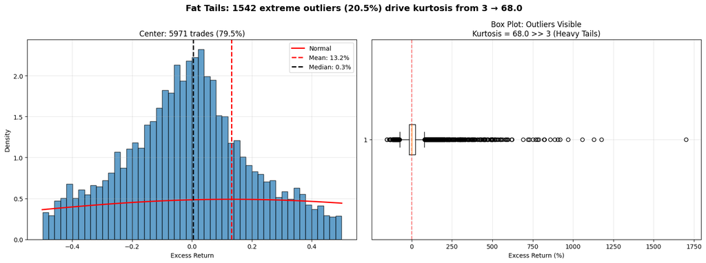

```python
skewness = skew(excess_array)
kurt = kurtosis(excess_array, fisher=False)

fig, (ax1, ax2) = plt.subplots(1, 2, figsize=(16, 6))
mean_excess = np.mean(excess_array)
median_excess = np.median(excess_array)
std_excess = np.std(excess_array)

# LEFT: Zoom into center (±50% or wherever most data is)
center_mask = np.abs(excess_array) <= 0.5  # ±50%
ax1.hist(excess_array[center_mask], bins=50, edgecolor='black', alpha=0.7, density=True)

# Overlay normal
x = np.linspace(-0.5, 0.5, 100)
normal_curve = norm.pdf(x, mean_excess, std_excess)
ax1.plot(x, normal_curve, 'r-', linewidth=2, label='Normal')

ax1.axvline(mean_excess, color='r', linestyle='--', linewidth=2, label=f'Mean: {mean_excess*100:.1f}%')
ax1.axvline(median_excess, color='black', linestyle='--', linewidth=2, label=f'Median: {median_excess*100:.1f}%')
ax1.set_xlabel('Excess Return')
ax1.set_ylabel('Density')
ax1.set_title(f'Center: {center_mask.sum()} trades ({center_mask.sum()/len(excess_array)*100:.1f}%)')
ax1.legend()
ax1.grid(alpha=0.3)

# RIGHT: Box plot showing outliers
ax2.boxplot(excess_array * 100, vert=False)
ax2.set_xlabel('Excess Return (%)')
ax2.set_title(f'Box Plot: Outliers Visible\nKurtosis = {(kurt).item():.1f} >> 3 (Heavy Tails)')
ax2.grid(alpha=0.3)
ax2.axvline(0, color='red', linestyle='--', alpha=0.5)

plt.suptitle(f'Fat Tails: {(~center_mask).sum()} extreme outliers ({(~center_mask).sum()/len(excess_array)*100:.1f}%) drive kurtosis from 3 → {(kurt).item():.1f}',
             fontsize=14, fontweight='bold')
plt.tight_layout()
plt.show()
```

**Figure 2:**

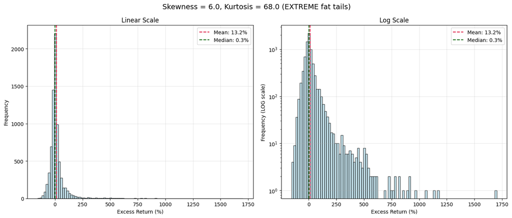

```python
fig, (ax1, ax2) = plt.subplots(1, 2, figsize=(14, 6))

# Linear scale
ax1.hist(excess_array * 100, bins=100, color="lightblue", edgecolor='black', alpha=0.7)
ax1.axvline(mean_excess * 100, color='crimson', linestyle='--', label=f'Mean: {mean_excess*100:.1f}%')
ax1.axvline(median_excess * 100, color='darkgreen', linestyle='--', label=f'Median: {median_excess*100:.1f}%')
ax1.set_xlabel('Excess Return (%)')
ax1.set_ylabel('Frequency')
ax1.set_title('Linear Scale')
ax1.legend()
ax1.grid(alpha=0.3)

# LOG scale - makes rare outliers visible
ax2.hist(excess_array * 100, color="lightblue", bins=100, edgecolor='black', alpha=0.7)
ax2.set_yscale('log')
ax2.axvline(mean_excess * 100, color='crimson', linestyle='--', label=f'Mean: {mean_excess*100:.1f}%')
ax2.axvline(median_excess * 100, color='darkgreen', linestyle='--', label=f'Median: {median_excess*100:.1f}%')
ax2.set_xlabel('Excess Return (%)')
ax2.set_ylabel('Frequency (LOG scale)')
ax2.set_title('Log Scale')
ax2.legend()
ax2.grid(alpha=0.3)

plt.suptitle(f'Skewness = {(skewness).item():.1f}, Kurtosis = {(kurt).item():.1f} (EXTREME fat tails)', fontsize=14)
plt.tight_layout()
plt.show()
```

**Figure 3:**

```python
# trades with greater htan 100 percent returns
outliers = returns_df[returns_df['excess_return'] > 1.0]

member_outlier_performance = outliers.groupby('owner_name').agg({
    'excess_return': ['mean', 'count']
}).round(4)

member_outlier_performance.columns = ['avg_excess_return', 'num_outlier_trades']

member_outlier_performance['avg_excess_return_pct'] = member_outlier_performance['avg_excess_return'] * 100

member_outlier_performance = member_outlier_performance.sort_values('avg_excess_return', ascending=False)


outlier_df = member_outlier_performance[['avg_excess_return_pct', 'num_outlier_trades']].copy()
outlier_df = outlier_df.reset_index()  # Moves member_name from index to column
outlier_df.columns = ['Member', 'Avg Excess Return (%)', 'Number of Outlier Trades']

display(HTML('<h3>Members with >100% Excess Return Trades</h3>'))
display(outlier_df.style.hide(axis='index'))
```

Members with >100% Excess Return Trades

| Member | Avg Excess Return (%) | Number of Outlier Trades |
| --- | --- | --- |
| Warren Davidson | 1177.130000 | 1 |
| James M Inhofe | 379.430000 | 10 |
| Shelley M Capito | 355.510000 | 46 |
| Robert J Wittman | 308.550000 | 1 |
| Gary C Peters | 281.500000 | 2 |
| Thomas R Carper | 278.920000 | 41 |
| Josh Gottheimer | 276.670000 | 100 |
| Pat Roberts | 276.070000 | 50 |
| Roger W Marshall | 268.600000 | 2 |
| Donald Sternoff Beyer | 255.770000 | 5 |
| John Curtis | 224.600000 | 12 |
| William Cassidy | 218.720000 | 24 |
| Alan S Lowenthal | 199.810000 | 10 |
| Jerry Moran | 198.310000 | 12 |
| Sheldon Whitehouse | 185.850000 | 9 |
| Brian Mast | 171.820000 | 2 |
| Patrick J Toomey | 171.470000 | 4 |
| Nancy Pelosi | 166.160000 | 2 |
| Katherine M Clark | 161.690000 | 4 |
| David B Mckinley | 159.200000 | 4 |
| Suzan K Delbene | 158.310000 | 5 |
| Christopher L Jacobs | 152.310000 | 1 |
| Greg Gianforte | 152.100000 | 5 |
| Lois Frankel | 148.310000 | 10 |
| Gilbert Cisneros | 146.810000 | 8 |
| Zoe Lofgren | 140.600000 | 2 |
| David A Perdue | 135.590000 | 44 |
| Earl Blumenauer | 131.130000 | 1 |
| K Michael Conaway | 129.230000 | 1 |
| John F Reed | 129.030000 | 12 |
| Susie Lee | 128.990000 | 6 |
| Mark Green | 125.790000 | 25 |
| Thomas H Tuberville | 125.070000 | 7 |
| Rick Scott | 117.730000 | 1 |
| Ron L Wyden | 115.250000 | 7 |
| Garret Graves | 115.010000 | 1 |
| Andrew Garbarino | 113.690000 | 1 |
| John Rutherford | 110.960000 | 3 |
| Dean Phillips | 104.280000 | 1 |
| John A Yarmuth | 103.250000 | 1 |
| Thomas Suozzi | 102.990000 | 1 |

**Table 3:**

Table 3 contains Members with average excess returns exceeding 100%. Rep. Warren Davidson stands out for leading the group with an average return of 1,177%, though this is skewed by one outlier trade. Sen. Perdue, Rep. Green, Sen. Carper, Sen. Capito, Sen. Roberts, and Rep. Gottheimer stand out for their large amounts of outlier trades and average excess returns between 125%-350% across 24 to 100 outlier trades.

These large outliers raise concerns that short holding periods may inflate percentage returns, so the dataset was split by holding period. Trades held for at least $365$ days were annualized for comparison with the S&P 500's CAGR, while short-term trades (less than $365$ days) were analyzed separately.

```python
returns_df["annualized_pct"] = (((returns_df["sell_price"]/returns_df["buy_price"])**(365/(returns_df["holding_days"]))) - 1)*100
annuals = returns_df[returns_df["holding_days"] >= 365]
annuals = annuals[annuals["annualized_pct"].notna()]
inter_annuals = returns_df[returns_df["holding_days"] < 365].copy()

# Create dataframe for annualized statistics
annuals_stats_df = pd.DataFrame({
    'Metric': ['Mean', 'Median', 'Variance', 'Std Dev', 'Max', 'Min'],
    'Value': [
        f"{annuals['annualized_pct'].mean():.4f}",
        f"{annuals['annualized_pct'].median():.4f}",
        f"{annuals['annualized_pct'].var():.4f}",
        f"{annuals['annualized_pct'].std():.4f}",
        f"{annuals['annualized_pct'].max():.4f}",
        f"{annuals['annualized_pct'].min():.4f}"
    ]
})

display(HTML('<h3>Annualized Returns Statistics (≥365 Days Held)</h3>'))
display(annuals_stats_df.style.hide(axis='index'))

# Create dataframe for inter-annual statistics
inter_annuals_stats_df = pd.DataFrame({
    'Metric': ['Mean', 'Median', 'Variance', 'Std Dev', 'Max', 'Min'],
    'Value': [
        f"{inter_annuals['profit_pct'].mean():.4f}",
        f"{inter_annuals['profit_pct'].median():.4f}",
        f"{inter_annuals['profit_pct'].var():.4f}",
        f"{inter_annuals['profit_pct'].std():.4f}",
        f"{inter_annuals['profit_pct'].max():.4f}",
        f"{inter_annuals['profit_pct'].min():.4f}"
    ]
})

display(HTML('<h3>Short Term Returns Statistics (<365 Days Held)</h3>'))
display(inter_annuals_stats_df.style.hide(axis='index'))
```

Annualized Returns Statistics (≥365 Days Held)

| Metric | Value |
| --- | --- |
| Mean | 13.4589 |
| Median | 11.3603 |
| Variance | 862.5861 |
| Std Dev | 29.3698 |
| Max | 651.2119 |
| Min | -88.6435 |

Short Term Returns Statistics (<365 Days Held)

| Metric | Value |
| --- | --- |
| Mean | 5.3116 |
| Median | 1.4291 |
| Variance | 1107.9861 |
| Std Dev | 33.2864 |
| Max | 511.8600 |
| Min | -84.8870 |

**Table 4: Annualized return statistics**  
**Table 5: Short term return statistics**

Table 4 displays summary statistics for the annualized returns. Members had an average annualized return of 13.45% with a median of 11.36% and a standard deviation of 29.37%. Table 5 shows short term trades had a lower mean and median return of 5.31% and 1.43% respectively, although a higher standard deviation of 33.3%. This suggests that while the longer term holdings consistently perform better, the short term trades are more volatile with most failing to beat the market.

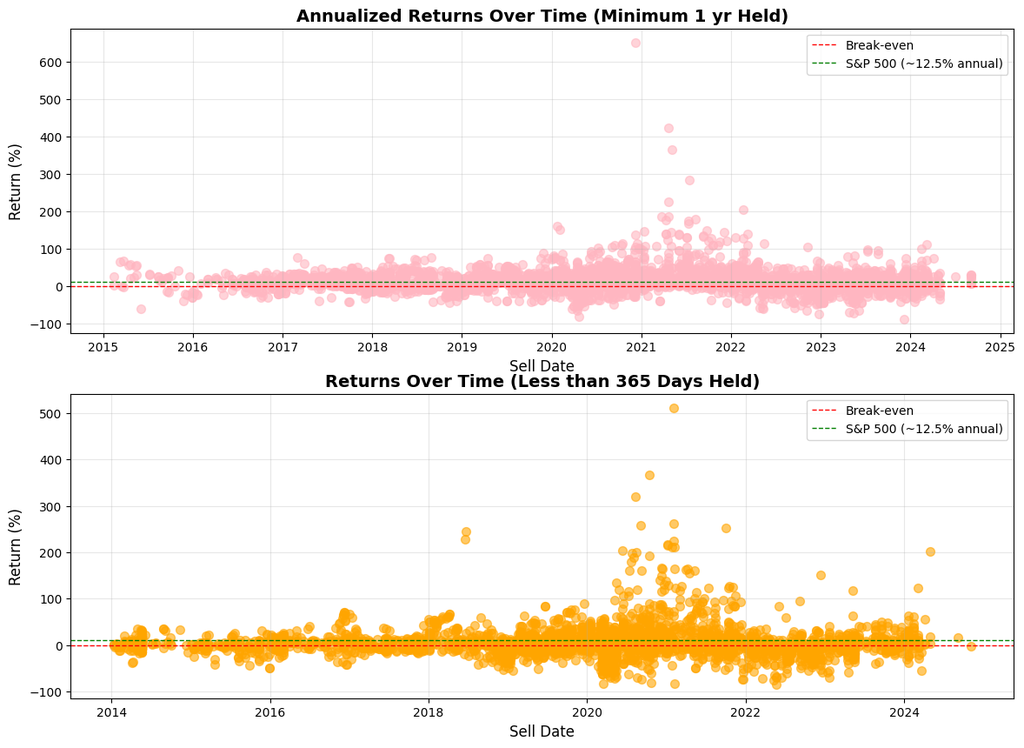

```python
fig, axes = plt.subplots(2, 1, figsize=(14, 10))

# Plot 1: Individual returns over time
axes[0].scatter(annuals['sell_date'], annuals['annualized_pct'],
                alpha=0.6, s=50, color='lightpink')
axes[0].axhline(y=0, color='red', linestyle='--', linewidth=1, label='Break-even')
axes[0].axhline(y=10, color='green', linestyle='--', linewidth=1, label='S&P 500 (~12.5% annual)')
axes[0].set_xlabel('Sell Date', fontsize=12)
axes[0].set_ylabel('Return (%)', fontsize=12)
axes[0].set_title('Annualized Returns Over Time (Minimum 1 yr Held)', fontsize=14, fontweight='bold')
axes[0].legend()
axes[0].grid(True, alpha=0.3)

axes[1].scatter(inter_annuals['sell_date'], inter_annuals['profit_pct'],
                alpha=0.6, s=50, color='orange')
axes[1].axhline(y=0, color='red', linestyle='--', linewidth=1, label='Break-even')
axes[1].axhline(y=10, color='green', linestyle='--', linewidth=1, label='S&P 500 (~12.5% annual)')
axes[1].set_xlabel('Sell Date', fontsize=12)
axes[1].set_ylabel('Return (%)', fontsize=12)
axes[1].set_title('Returns Over Time (Less than 365 Days Held)', fontsize=14, fontweight='bold')
axes[1].legend()
axes[1].grid(True, alpha=0.3)
```

**Figure 4:**

Figure 4 plots the annualized returns and short term trades. Both plots confirm that most trades cluster around the S&P 500 benchmark. Notably, volume and extreme values are most apparent during the pandemic (2020-2022).

### Statistics by member

From the Members overall portfolios and annualized trades, we get a generalized view of their performance which reveals statistically significant excess returns with a heavily-tailed distribution affected by extreme outliers. To examine if the outperformance is concentrated among a small number of traders, individual member performance can be analyzed.

```python
#stats by member
member_stats = annuals.groupby('owner_name').agg({
    'annualized_pct': ['mean', 'median', 'count'],
    'holding_days': 'mean'
}).round(2)

#minimum of 5 trades
member_stats = member_stats[member_stats[('annualized_pct', 'count')] >= 5]
```

To focus on Members with sufficient trading activity, this analysis includes only those with at least 5 annualized trades (holding period of at least 365 days), resulting in a subset of 58 Members. Figure 5 visualizes the top 30 performers based on average annualized returns.

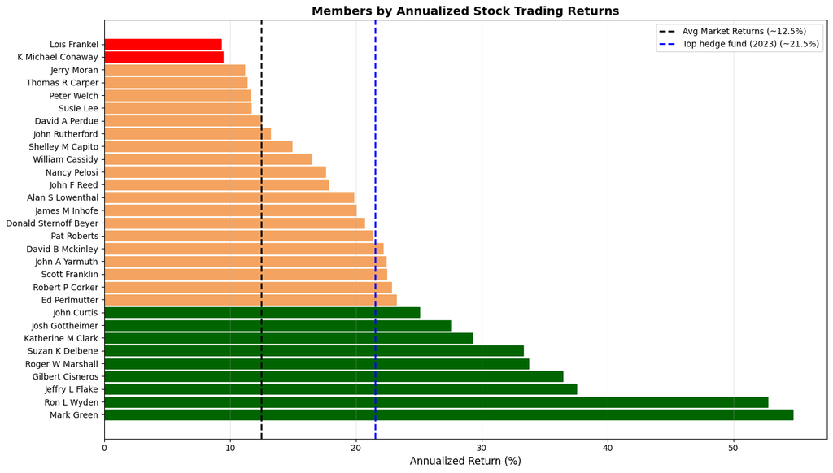

```python
member_stats = member_stats.sort_values(
    by=("annualized_pct", "mean"),
    ascending=False
)

top_30 = member_stats.head(30)
fig, ax = plt.subplots(figsize=(14, 8))

# Plot horizontal bars
bars = ax.barh(
    range(len(top_30)),
    top_30["annualized_pct"]["mean"],
    color="steelblue"
)

# Add benchmark lines
ax.axvline(x=12.5, color='black', linestyle='--', linewidth=2, label='Avg Market Returns (~12.5%)')
ax.axvline(x=21.5, color='blue', linestyle='--', linewidth=2, label='Top hedge fund (2023) (~21.5%)')

# Color bars based on performance
for i, bar in enumerate(bars):
    value = top_30.iloc[i]["annualized_pct"]["mean"]
    if value > 25:
        bar.set_color('darkgreen')
    elif value > 10:
        bar.set_color('sandybrown')
    else:
        bar.set_color('red')

# Label and styling
ax.set_yticks(range(len(top_30)))
ax.set_yticklabels(top_30.index)
ax.set_xlabel('Annualized Return (%)', fontsize=12)
ax.set_title('Members by Annualized Stock Trading Returns', fontsize=14, fontweight='bold')
ax.legend()
ax.grid(axis='x', alpha=0.3)

plt.tight_layout()
plt.show()
```

**Figure 5:**

Figure 5 shows that 24 of the top 30 Members or 80% (only 42% of the total 58) beat the S&P 500's CAGR of 12.49% during the same period. Thus, the 6 that did not indicate that the remaining 28 members not included in the top 30 also did not beat the Market benchmark (58% of the total 58). Notably, 14 of the top 15 Members additionally beat the performance of Cotaue Management in 2023 at gains of 21.5%, one of the top performers of the year<sup>[7]</sup>. While this comparison is not statistically sound, it is useful for interpreting Congressional returns against some of the best professional managers.

A Shapiro-Wilk normality test, as well as a Q-Q plot of the returns was performed on both the trade-level and Member-level annualized returns data. The results are shown below.

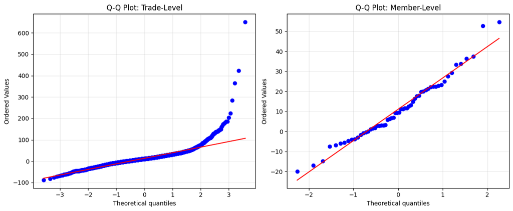

Shapiro-Wilk Test For Normality

| Metric | Value |
| --- | --- |
| Statistic (TL) | 0.785734 |
| P-value (TL) | 0.000000 |
| Significance (TL) | Not Normal |
| Statistic(MEM) | 0.971407 |
| P-value (MEM) | 0.186637 |
| Significance (MEM) | Normal |

```python
# annualized trades
stat_t, p_t = shapiro(annuals['annualized_pct'])

# grouped by member
member_avgs = annuals.groupby('owner_name')['annualized_pct'].agg(['mean', 'count'])
member_avgs = member_avgs[member_avgs['count'] >= 5]['mean']

stat_c, p_c = shapiro(member_avgs)

#  Q-Q plots
fig, (ax1, ax2) = plt.subplots(1, 2, figsize=(12, 5))

stats.probplot(annuals['annualized_pct'], dist="norm", plot=ax1)
ax1.set_title('Q-Q Plot: Trade-Level')
ax1.grid(alpha=0.3)

stats.probplot(member_avgs, dist="norm", plot=ax2)
ax2.set_title('Q-Q Plot: Member-Level')
ax2.grid(alpha=0.3)

plt.tight_layout()
plt.show()

shapiros_table = pd.DataFrame({
    'Metric': [
        'Statistic (TL)',
        'P-value (TL)',
        'Significance (TL)',
        'Statistic(MEM)',
        'P-value (MEM)',
        'Significance (MEM)'
    ],
    'Value': [
        stat_t,
        p_t,
        'Not Normal' if p_t < 0.05 else 'Normal',
        stat_c,
        p_c,
        'Not Normal' if p_c < 0.05 else 'Normal',
    ]
})

display(HTML('<h3>Shapiro-Wilk Test For Normality</h3>'))
display(shapiros_table.style.hide(axis='index'))
```

**Figure 6: Q-Q Plots for Trade-level and Member-level data**  
**Table 6: Shapiro-Wilk test for Normality, TL = Trade-level, MEM=Member-level**

From Table 6 and at a significance level of $\alpha = 0.05$, we can observe that the trade-level data is not normally distributed (p-value = 0), while the Member level data is (p-value = 0.18). The Q-Q plots in Figure 6 visualize this, with extreme values in the trade-level (left) exceeding those of a normal distribution, confirming that a small number of exceptional trades influence non-normality. The Member-level plot (right) is close to the theoretical normal line, thus the distribution of Member's portfolios is approximately normal. This suggests that the individual trades have high variability with large outlier values, but the Members themselves trade with a normal distribution.

```python
# Wilcoxon signed-rank test: Are annualized returns > S&P 500?
trade_returns = annuals['annualized_pct'].values
sandp_cagr = cagr.values*100
stat_wilcox, p_wilcox = stats.wilcoxon(trade_returns - sandp_cagr, alternative='greater')

# Effect Size: Hodges-Lehmann Estimator (non-parametric median difference)
differences = trade_returns - sandp_cagr
median_excess = np.median(differences)
mean_excess = np.mean(differences)
std_excess = np.std(differences)


# Rank-biserial correlation (effect size for Wilcoxon)
n = len(trade_returns)
r = 1 - (2*stat_wilcox) / (n*(n+1)/2)  # Effect size

# Create DataFrame for Trade-Level Analysis
trade_level_df = pd.DataFrame({
    'Metric': [
        'Sample size',
        'Congressional mean return (%)',
        'S&P 500 benchmark (%)',
        'Mean excess return (%)',
        'Median excess return (%)',
        'Excess Return Volatility (%)',
        'Wilcoxon test statistic',
        'P-value',
        'Significance',
        'Effect size (rank-biserial r)',
        'Interpretation'
    ],
    'Value': [
        f"{n} trades",
        f"{np.mean(trade_returns):.2f}",
        f"{(sandp_cagr).item():.2f}",
        f"{mean_excess:.2f}",
        f"{median_excess:.2f}",
        f"{std_excess:.2f}",
        f"{stat_wilcox:.2f}",
        f"{p_wilcox:.6f}",
        '***' if p_wilcox < 0.001 else '**' if p_wilcox < 0.01 else '*' if p_wilcox < 0.05 else 'ns',
        f"{r:.4f}",
        'Small' if abs(r) < 0.3 else 'Medium' if abs(r) < 0.5 else 'Large'
    ]
})

display(HTML('<h3>Trade-Level Analysis (Wilcoxon Signed-Rank Test)</h3>'))
display(trade_level_df.style.hide(axis='index'))


# member data - normally dist

# one sample t-test: are member avg greater than sp500 cagr
member_returns = member_avgs.values
t_stat, p_ttest = stats.ttest_1samp(member_returns, sandp_cagr, alternative='greater')

# effect size
member_mean = np.mean(member_returns)
member_std = np.std(member_returns, ddof=1)
cohens_d = (member_mean - sandp_cagr) / member_std

member_level_df = pd.DataFrame({
    'Metric': [
        'Sample size',
        'Member mean return (%)',
        'Member Volatility (%)',
        'S&P 500 benchmark (%)',
        'Mean excess return (%)',
        'Excess Return Volatility (%)',
        'T-statistic',
        'P-value',
        'Significance',
        "Effect size (Cohen's d)",
        'Interpretation'
    ],
    'Value': [
        f"{len(member_returns)} members",
        f"{member_mean:.2f}",
        f"{member_std:.2f}",
        f"{(sandp_cagr).item():.2f}",
        f"{(member_mean - sandp_cagr).item():.2f}",
        f"{np.std(member_returns - sandp_cagr).item():.2f}",
        f"{t_stat:.4f}",
        f"{p_ttest:.6f}",
        '***' if p_ttest < 0.001 else '**' if p_ttest < 0.01 else '*' if p_ttest < 0.05 else 'ns',
        f"{(cohens_d).item():.4f}",
        'Small' if abs(cohens_d) < 0.5 else 'Medium' if abs(cohens_d) < 0.8 else 'Large'
    ]
})

display(HTML('<h3>Member-Level Analysis (One-Sample T-Test)</h3>'))
display(member_level_df.style.hide(axis='index'))

summary_df = pd.DataFrame({
    'Analysis Level': ['Trade-Level', 'Member-Level'],
    'N': [n, len(member_returns)],
    'Mean Return (%)': [np.mean(trade_returns), member_mean],
    'Benchmark (%)': [sandp_cagr, sandp_cagr],
    'Mean Excess (%)': [mean_excess, member_mean - sandp_cagr],
    'Test Used': ['Wilcoxon', 'T-test'],
    'P-value': [f"{p_wilcox:.6f}", f"{p_ttest:.6f}"],
    'Effect Size': [f"{r:.4f} (r)", f"{(cohens_d).item():.4f} (d)"],
    'Significance': [
        '***' if p_wilcox < 0.001 else '**' if p_wilcox < 0.01 else '*' if p_wilcox < 0.05 else 'ns',
        '***' if p_ttest < 0.001 else '**' if p_ttest < 0.01 else '*' if p_ttest < 0.05 else 'ns'
    ]
})

display(HTML('<h3>Summary Comparison</h3>'))
display(summary_df.style.hide(axis='index'))
```

Trade-Level Analysis (Wilcoxon Signed-Rank Test)

| Metric | Value |
| --- | --- |
| Sample size | 4190 trades |
| Congressional mean return (%) | 13.46 |
| S&P 500 benchmark (%) | 12.49 |
| Mean excess return (%) | 0.97 |
| Median excess return (%) | -1.13 |
| Excess Return Volatility (%) | 29.37 |
| Wilcoxon test statistic | 4221965.00 |
| P-value | 0.984093 |
| Significance | ns |
| Effect size (rank-biserial r) | 0.0383 |
| Interpretation | Small |

Member-Level Analysis (One-Sample T-Test)

| Metric | Value |
| --- | --- |
| Sample size | 58 members |
| Member mean return (%) | 11.05 |
| Member Volatility (%) | 15.51 |
| S&P 500 benchmark (%) | 12.49 |
| Mean excess return (%) | -1.44 |
| Excess Return Volatility (%) | 15.38 |
| T-statistic | -0.7057 |
| P-value | 0.758376 |
| Significance | ns |
| Effect size (Cohen's d) | -0.0927 |
| Interpretation | Small |

Summary Comparison

| Analysis Level | N | Mean Return (%) | Benchmark (%) | Mean Excess (%) | Test Used | P-value | Effect Size | Significance |
| --- | --- | --- | --- | --- | --- | --- | --- | --- |
| Trade-Level | 4190 | 13.458885 | [12.49044018] | 0.968445 | Wilcoxon | 0.984093 | 0.0383 (r) | ns |
| Member-Level | 58 | 11.053132 | [12.49044018] | [-1.43730782] | T-test | 0.758376 | -0.0927 (d) | ns |

**Table 7: Trade-level summary statistics and Wilcoxon-Signed Rank test for significance**  
**Table 8: Member-level summary statistics and t-test for significance** **Table 9: Comparison of outputs from Tables 7 and 8**

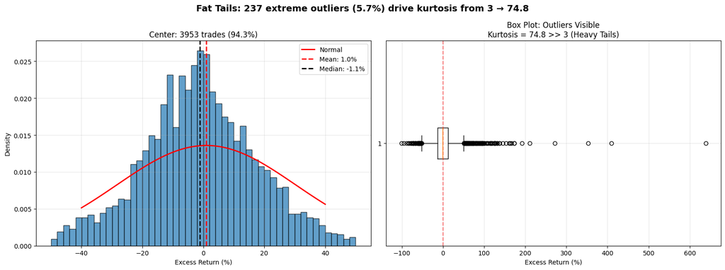

```python
#skewness and kurtosis for
skewness = skew(differences)
kurt = kurtosis(differences, fisher=False)

fig, (ax1, ax2) = plt.subplots(1, 2, figsize=(16, 6))

# LEFT: Zoom into center (±50% or wherever most data is)
center_mask = np.abs(differences) <= 50  # ±50%
ax1.hist(differences[center_mask], bins=50, edgecolor='black', alpha=0.7, density=True)

# Overlay normal
x = np.linspace(-40, 40, 100)
normal_curve = norm.pdf(x, mean_excess, std_excess)
ax1.plot(x, normal_curve, 'r-', linewidth=2, label='Normal')

ax1.axvline(mean_excess, color='r', linestyle='--', linewidth=2, label=f'Mean: {mean_excess:.1f}%')
ax1.axvline(median_excess, color='black', linestyle='--', linewidth=2, label=f'Median: {median_excess:.1f}%')
ax1.set_xlabel('Excess Return (%)')
ax1.set_ylabel('Density')
ax1.set_title(f'Center: {center_mask.sum()} trades ({(center_mask.sum()/len(differences)*100):.1f}%)')
ax1.legend()
ax1.grid(alpha=0.3)

# RIGHT: Box plot showing outliers
ax2.boxplot(differences, vert=False)
ax2.set_xlabel('Excess Return (%)')
ax2.set_title(f'Box Plot: Outliers Visible\nKurtosis = {(kurt).item():.1f} >> 3 (Heavy Tails)')
ax2.grid(alpha=0.3)
ax2.axvline(0, color='red', linestyle='--', alpha=0.5)

plt.suptitle(f'Fat Tails: {(~center_mask).sum()} extreme outliers ({((~center_mask).sum()/len(differences))*100:.1f}%) drive kurtosis from 3 → {(kurt).item():.1f}',
             fontsize=14, fontweight='bold')
plt.tight_layout()
plt.show()
```

**Figure 7:**

Figure 7 shows the distribution of annualized excess returns. The histogram (left) shows that 94.3% of trades fall within 50 percentage points of 0. However, the box plot (right) reveals that outliers making up just 5.7% of the data drive the kurtosis to 74.8. This indicates that while most annualized trades perform near the benchmark, a small subset achieves extremely high or low returns creating the heavy-tailed distribution seen previously.

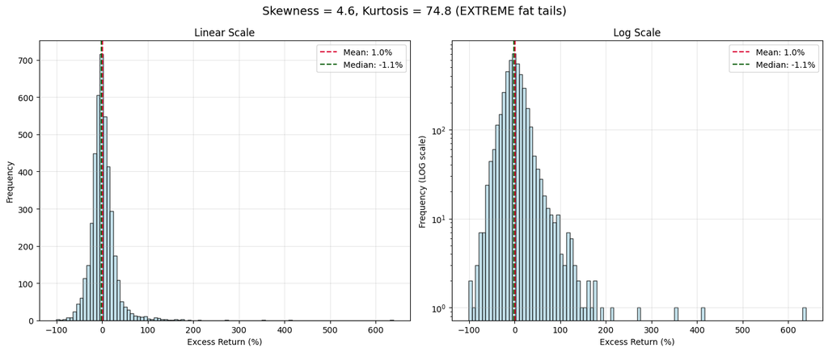

```python
fig, (ax1, ax2) = plt.subplots(1, 2, figsize=(14, 6))

# Linear scale
ax1.hist(differences, bins=100, color="lightblue", edgecolor='black', alpha=0.7)
ax1.axvline(mean_excess, color='crimson', linestyle='--', label=f'Mean: {mean_excess:.1f}%')
ax1.axvline(median_excess, color='darkgreen', linestyle='--', label=f'Median: {median_excess:.1f}%')
ax1.set_xlabel('Excess Return (%)')
ax1.set_ylabel('Frequency')
ax1.set_title('Linear Scale')
ax1.legend()
ax1.grid(alpha=0.3)

# LOG scale - makes rare outliers visible
ax2.hist(differences, color="lightblue", bins=100, edgecolor='black', alpha=0.7)
ax2.set_yscale('log')
ax2.axvline(mean_excess, color='crimson', linestyle='--', label=f'Mean: {mean_excess:.1f}%')
ax2.axvline(median_excess, color='darkgreen', linestyle='--', label=f'Median: {median_excess:.1f}%')
ax2.set_xlabel('Excess Return (%)')
ax2.set_ylabel('Frequency (LOG scale)')
ax2.set_title('Log Scale')
ax2.legend()
ax2.grid(alpha=0.3)

plt.suptitle(f'Skewness = {(skewness).item():.1f}, Kurtosis = {(kurt).item():.1f} (EXTREME fat tails)', fontsize=14)
plt.tight_layout()
plt.show()
```

**Figure 8:**

Figure 8 visualizes histogram of the excess returns for the annualized trades, where we can see that most trades are grouped around 0, with the extreme outliers becoming more apparent on the log scale (right).

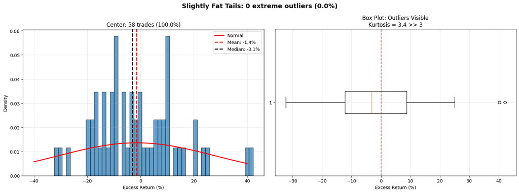

```python
#skewness and kurtosis for members
member_excess = member_returns - sandp_cagr
member_skewness = skew(member_excess)
member_kurtosis = kurtosis(member_excess, fisher=False)
member_mean_excess = np.mean(member_excess)
member_median_excess = np.median(member_excess)

fig, (ax1, ax2) = plt.subplots(1, 2, figsize=(16, 6))

# LEFT: Zoom into center (±50% or wherever most data is)
center_mask = np.abs(member_excess) <= 50  # ±50%
ax1.hist(member_excess[center_mask], bins=50, edgecolor='black', alpha=0.7, density=True)

# Overlay normal
x = np.linspace(-40, 40, 100)
normal_curve = norm.pdf(x, member_mean_excess, std_excess)
ax1.plot(x, normal_curve, 'r-', linewidth=2, label='Normal')

ax1.axvline(member_mean_excess, color='r', linestyle='--', linewidth=2, label=f'Mean: {member_mean_excess:.1f}%')
ax1.axvline(member_median_excess, color='black', linestyle='--', linewidth=2, label=f'Median: {member_median_excess:.1f}%')
ax1.set_xlabel('Excess Return (%)')
ax1.set_ylabel('Density')
ax1.set_title(f'Center: {center_mask.sum()} trades ({(center_mask.sum()/len(member_excess)*100):.1f}%)')
ax1.legend()
ax1.grid(alpha=0.3)

# RIGHT: Box plot showing outliers
ax2.boxplot(member_excess, vert=False)
ax2.set_xlabel('Excess Return (%)')
ax2.set_title(f'Box Plot: Outliers Visible\nKurtosis = {(member_kurtosis).item():.1f} >> 3')
ax2.grid(alpha=0.3)
ax2.axvline(0, color='red', linestyle='--', alpha=0.5)

plt.suptitle(f'Slightly Fat Tails: {(~center_mask).sum()} extreme outliers ({(~center_mask).sum()/len(member_excess)*100:.1f}%)',
             fontsize=14, fontweight='bold')
plt.tight_layout()
plt.show()
```

**Figure 9:**

Figure 9 shows that all 58 Congressional Members fall within 50 percentage points of 0, with no extreme outliers. However, the kurtosis is still slightly larger than what is expected from a normal distribution (3.4 vs 3.0). This is likely due to values that fall within 50 percentage points, but are more extreme like those we can observe around 40 and -30. This suggests that when annualized trades are grouped by the Members who made them, the excess returns are more normally distributed, which is similar to the findings from Figure 6.

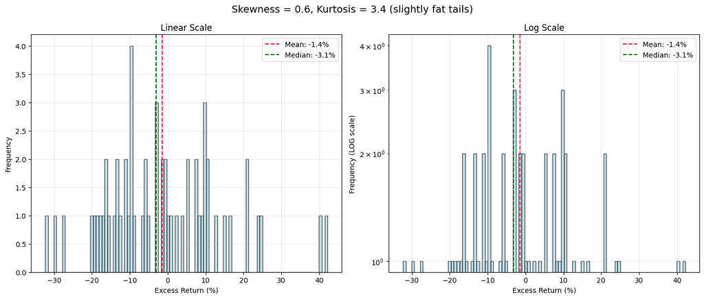

```python
fig, (ax1, ax2) = plt.subplots(1, 2, figsize=(14, 6))

# Linear scale
ax1.hist(member_excess, bins=100, color="lightblue", edgecolor='black', alpha=0.7)
ax1.axvline(member_mean_excess, color='crimson', linestyle='--', label=f'Mean: {member_mean_excess:.1f}%')
ax1.axvline(member_median_excess, color='darkgreen', linestyle='--', label=f'Median: {member_median_excess:.1f}%')
ax1.set_xlabel('Excess Return (%)')
ax1.set_ylabel('Frequency')
ax1.set_title('Linear Scale')
ax1.legend()
ax1.grid(alpha=0.3)

# LOG scale - makes rare outliers visible
ax2.hist(member_excess, color="lightblue", bins=100, edgecolor='black', alpha=0.7)
ax2.axvline(member_mean_excess, color='crimson', linestyle='--', label=f'Mean: {member_mean_excess:.1f}%')
ax2.axvline(member_median_excess, color='darkgreen', linestyle='--', label=f'Median: {member_median_excess:.1f}%')
ax2.set_yscale('log')
ax2.set_xlabel('Excess Return (%)')
ax2.set_ylabel('Frequency (LOG scale)')
ax2.set_title('Log Scale')
ax2.legend()
ax2.grid(alpha=0.3)

plt.suptitle(f'Skewness = {(member_skewness).item():.1f}, Kurtosis = {(member_kurtosis).item():.1f} (slightly fat tails)', fontsize=14)
plt.tight_layout()
plt.show()
```

**Figure 9:**

Figure 9 shows histograms of the excess returns at the Member-level on a linear (left) and log scale (right). Unlike the trade-level analysis where the log scale drastically changed the visualization, making the heavy-tail more apparent, the log scale here shows minimal difference. We can observe that the data is relatively evenly distributed around the mean. This reinforces previous findings that the Member-level trades have normal excess returns.

It is important to note a difference between the analyses so far. The initial trade analysis in Table 1 compared each trades return to the S&P 500 over that specific holding period. In the annualized returns analysis, the benchmark is a single S&P 500 CAGR of 12.49% calculated over the entire time period from 2012-2024. This means that some periods where Members outperformed during market downturns or underperformed during a bullish period might be less apparent compared to one average CAGR.

### Sharpe Ratios

```python
# 3-Month Treasury Bill Secondary Market Rate, Discount Basis
tbr = pd.read_csv("DTB3.csv")
tbr_avg = tbr["DTB3"].mean()
risk_free_rate = tbr_avg / 100

# Create date range for all months from 2012-2024
date_range = pd.date_range(start='2012-08-01', end='2024-10-01', freq='MS')

# For each month, calculate the average return of positions closed that month
monthly_returns = []

for month_start in date_range:
    month_end = month_start + pd.offsets.MonthEnd(0)

    # Find all trades that were sold in this month
    trades_closed = annuals[
        (annuals['sell_date'] >= month_start) &
        (annuals['sell_date'] <= month_end)
    ]

    if len(trades_closed) > 0:
        # Use annualized_pct converted to monthly equivalent
        # For positions held >= 365 days, convert annual return to monthly
        avg_annual_return = trades_closed['annualized_pct'].mean()
        monthly_return = ((1 + avg_annual_return/100) ** (1/12) - 1) * 100
        monthly_returns.append(monthly_return)
    else:
        # No positions closed this month - use 0 return
        monthly_returns.append(0)

monthly_returns = np.array(monthly_returns)

# Calculate Sharpe Ratio
monthly_risk_free = risk_free_rate / 12  # annual to month
excess_returns = (monthly_returns / 100) - monthly_risk_free
sharpe = np.mean(excess_returns) / np.std(excess_returns) * np.sqrt(12)

# Create summary DataFrame
sharpe_summary = pd.DataFrame({
    'Metric': [
        'Number of months analyzed',
        'Months with trades',
        'Average monthly return (%)',
        'Monthly volatility (%)',
        'Risk-free rate (monthly, %)',
        'Sharpe Ratio'
    ],
    'Value': [
        len(monthly_returns),
        (monthly_returns != 0).sum(),
        f"{np.mean(monthly_returns):.4f}",
        f"{np.std(monthly_returns):.4f}",
        f"{monthly_risk_free*100:.4f}",
        f"{sharpe:.4f}"
    ]
})

display(HTML('<h3>Congressional Monthly Returns - Sharpe Ratio (2012-2024)</h3>'))
display(sharpe_summary.style.hide(axis='index'))
```

Congressional Monthly Returns - Sharpe Ratio (2012-2024)

| Metric | Value |
| --- | --- |
| Number of months analyzed | 147 |
| Months with trades | 113 |
| Average monthly return (%) | 0.7781 |
| Monthly volatility (%) | 1.1627 |
| Risk-free rate (monthly, %) | 0.1151 |
| Sharpe Ratio | 1.9753 |

**Table 10: Sharpe Ratio for Monthly Returns from stock trades by Members of Congress from 2012-2024 (held for at least 365 days)**

```python
%%capture
sandp_data = yf.download("^GSPC", start="2012-08-01", end="2024-10-01", interval="1mo")
```

```python
# sp500 sharpe ratio
sandp_monthly_returns = sandp_data['Close'].pct_change().dropna() * 100

# same risk free rate used above
monthly_risk_free = risk_free_rate / 12

excess_returns_sandp = (sandp_monthly_returns / 100) - monthly_risk_free

mean_excess = excess_returns_sandp.mean().item()
std_excess = excess_returns_sandp.std().item()
sharpe_sandp = mean_excess / std_excess * np.sqrt(12)

mean_monthly_return = sandp_monthly_returns.mean().item()
std_monthly_return = sandp_monthly_returns.std().item()
annualized_return = ((1 + mean_monthly_return/100)**12 - 1) * 100

# Create summary DataFrame
sandp_summary = pd.DataFrame({
    'Metric': [
        'Number of months',
        'Average monthly return (%)',
        'Monthly volatility (%)',
        'Risk-free rate (monthly, %)',
        'Annualized return (%)',
        'Sharpe Ratio'
    ],
    'Value': [
        len(sandp_monthly_returns),
        f"{mean_monthly_return:.4f}",
        f"{std_monthly_return:.4f}",
        f"{monthly_risk_free*100:.4f}",
        f"{annualized_return:.4f}",
        f"{sharpe_sandp:.4f}"
    ]
})

display(HTML('<h3>S&P 500 Sharpe Ratio (2012-2024)</h3>'))
display(sandp_summary.style.hide(axis='index'))
```

S&P 500 Sharpe Ratio (2012-2024)

| Metric | Value |
| --- | --- |
| Number of months | 145 |
| Average monthly return (%) | 1.0622 |
| Monthly volatility (%) | 4.1259 |
| Risk-free rate (monthly, %) | 0.1151 |
| Annualized return (%) | 13.5181 |
| Sharpe Ratio | 0.7952 |

**Table 11:**

To assess risk-adjusted performance, Sharpe Ratios for both congressional annualized trades (converted to monthly) and the S&P 500 were calculated, using the 3-month Treasury Bill rate as the risk free rate. Tables 10 and 11 reveal that Members achieved a Sharpe Ratio of 1.975 compared to the S&P 500's 0.795. This means that congressional trades delivered substantially higher returns for the risk they took on. More specifically, Members earned 1.975 units of excess returns for every unit of risk they take on. Note, that a Sharpe Ratio less than 1 is considered sub-optimal, greater than one is considered good, and over 2 is considered very good<sup>[8]</sup>. This suggests that the Members' annualized trades are characterized by consistent, lower-risk positions rather than bets on volatile positions. Whether this indicates an information advantage that reduces the uncertainty or conservative portfolio management would require additional research.

### Committees

```python
with open('committee-membership-current.yaml', 'r') as f:
    committees_membership = yaml.safe_load(f)

with open('committees-current.yaml', 'r', encoding='utf-8') as f:
    committees_current = yaml.safe_load(f)

member_committees = []
for bioguide_id, committees in committees_membership.items():
    for member in committees:
        member_committees.append({
            'bioguide_id': bioguide_id,
            'member': member
        })

committees_df = pd.DataFrame(member_committees)
```

```python
import re

member_to_committees = {}

for committee_id, members_list in committees_membership.items():
    for member_dict in members_list:
        member_name = member_dict.get('name')
        if member_name:
            # Clean the name
            cleaned_name = clean_name(member_name)

            # Add to mapping
            if cleaned_name not in member_to_committees:
                member_to_committees[cleaned_name] = []
            member_to_committees[cleaned_name].append(committee_id)
```

```python
# Step 2: Create mapping of thomas_id to committee names (exclude subcommittees)
thomas_id_to_name = {}

for committee in committees_current:
    # Only process main committees (they have 'type' at top level)
    if 'type' in committee and 'thomas_id' in committee and 'name' in committee:
        thomas_id = committee['thomas_id']
        committee_name = committee['name']
        thomas_id_to_name[thomas_id] = committee_name

thomas_id_to_name["HSZS"] = 'SC Between US and CCP'
```

```python
# Step 3: Create mapping from member name to their committee names (with full names)
member_to_committee_names = {}

for member_name, committee_ids in member_to_committees.items():
    committee_names = []
    for committee_id in committee_ids:
        # Look up the full committee name
        if committee_id in thomas_id_to_name:
            committee_names.append(thomas_id_to_name[committee_id])

    if committee_names:
        member_to_committee_names[member_name] = committee_names
```

```python
# Step 4: Add committees column to returns_df
# Match members by their cleaned names (returns_df already has cleaned owner_name)

def get_committees_for_member(owner_name):
    """
    Get comma-separated list of committees for a member.
    Returns empty string if no match found.
    """
    if pd.isna(owner_name):
        return ""

    # Direct match first
    if owner_name in member_to_committee_names:
        committees = member_to_committee_names[owner_name]
        return ".".join(committees)

    # If no direct match, return empty string
    return ""

# Add the committees column
returns_df['committees'] = returns_df['owner_name'].apply(get_committees_for_member)
```

Previous research in this area discusses Congressional committees and their unique access to a variety of decision-making information. Top "influential" committees were determined from this prior research and from OpenSecrets, who considers influential committees those with the largest revolving door profiles. This refers to members who move between committee positions and private sector roles in the relevant industry.Due to difficulties sourcing historic committee information for all Members in the dataset, at all periods of service, the analysis focuses only on active members and their current committee assignments. There are 39 unique committees with active members in the dataset, and for the purpose of this analysis, only committees with more than 10 combined trades are considered to ensure a more sufficient sample size. Here all Member trades are considered in terms of profit percentage and regardless of holding time (same data as Table 1, not using annualized percentages).

```python
# Step 1: Explode the committees column so each trade-committee gets its own row
# First, filter to only trades with committee data
trades_with_committees = returns_df[returns_df["committees"] != ""].copy()

# Split the comma-separated committees into lists
trades_with_committees['committee_list'] = trades_with_committees['committees'].str.split('.')

# Explode so each committee gets its own row
committee_trades = trades_with_committees.explode('committee_list')

# Step 2: Calculate statistics by committee
committee_stats = committee_trades.groupby('committee_list').agg({
    'profit_pct': ['mean', 'median', 'count'],
    'holding_days': 'mean'
}).round(2)

committee_stats.columns = ['avg_profit_pct', 'median_profit_pct', 'num_trades', 'avg_holding_days']

# Filter to committees with at least 10 trades for statistical significance
committee_stats = committee_stats[committee_stats['num_trades'] >= 10]

# Sort by average profit percentage
committee_stats = committee_stats.sort_values('avg_profit_pct', ascending=False)

# Get top 20
top_20_committees = committee_stats.head(20).reset_index()
top_20_committees.columns = ['Committee', 'Avg Profit (%)', 'Median Profit (%)', 'Number of Trades', 'Avg Holding Days']

display(HTML('<h3>Top 20 Committees by Average Profit % (Minimum 10 Trades)</h3>'))
display(top_20_committees.style.hide(axis='index'))
```

Top 20 Committees by Average Profit % (Minimum 10 Trades)

| Committee | Avg Profit (%) | Median Profit (%) | Number of Trades | Avg Holding Days |
| --- | --- | --- | --- | --- |
| House Permanent Select Committee on Intelligence | 78.250000 | 28.330000 | 569 | 729.830000 |
| House Committee on Financial Services | 76.540000 | 24.700000 | 594 | 732.500000 |
| House Committee on Foreign Affairs | 66.410000 | -5.870000 | 17 | 580.530000 |
| Senate Committee on Homeland Security and Governmental Affairs | 58.510000 | -1.380000 | 15 | 480.600000 |
| Senate Committee on Armed Services | 55.870000 | 0.230000 | 16 | 473.060000 |
| Senate Committee on Commerce, Science, and Transportation | 33.930000 | 16.990000 | 176 | 828.020000 |
| Senate Select Committee on Intelligence | 33.000000 | 12.790000 | 169 | 911.320000 |
| Senate Committee on Indian Affairs | 27.040000 | 9.580000 | 201 | 794.250000 |
| Senate Committee on Agriculture, Nutrition, and Forestry | 25.690000 | 7.840000 | 221 | 757.310000 |
| SC Between US and CCP | 24.230000 | 15.920000 | 37 | 541.460000 |
| House Committee on Appropriations | 23.850000 | 16.440000 | 578 | 596.300000 |
| Senate Committee on Veterans' Affairs | 20.260000 | 2.700000 | 269 | 507.660000 |
| House Committee on Natural Resources | 19.080000 | 12.730000 | 383 | 468.290000 |
| Senate Committee on Appropriations | 16.270000 | 1.150000 | 375 | 553.540000 |
| Senate Committee on Finance | 14.690000 | 1.830000 | 267 | 888.120000 |
| United States Senate Caucus on International Narcotics Control | 14.670000 | 1.680000 | 249 | 921.100000 |
| Senate Committee on the Judiciary | 14.520000 | 1.680000 | 269 | 881.800000 |
| Commission on Security and Cooperation in Europe | 14.340000 | 0.390000 | 250 | 914.320000 |
| Senate Committee on Environment and Public Works | 14.340000 | 0.390000 | 250 | 914.320000 |
| House Committee on Armed Services | 12.080000 | 3.280000 | 81 | 350.980000 |

**Table 12**

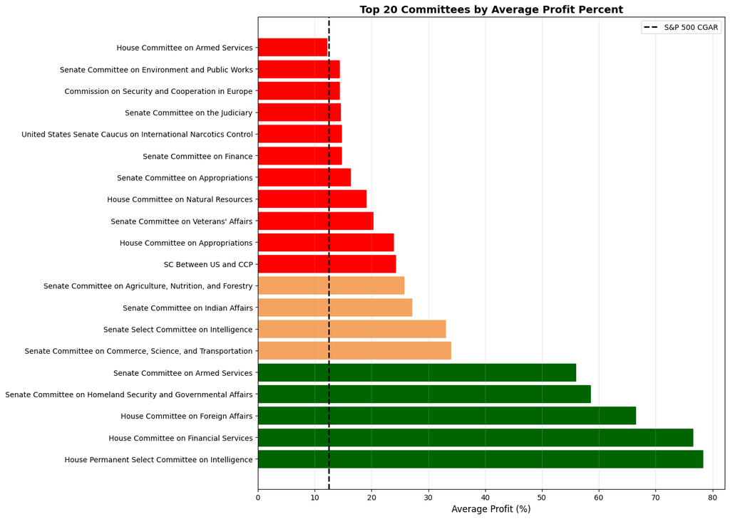

```python
# Visualize top 20 committees
fig, ax = plt.subplots(figsize=(14, 10))

top_20 = committee_stats.head(20)

bars = ax.barh(range(len(top_20)), top_20['avg_profit_pct'], color='steelblue')

# Add benchmark line
ax.axvline(x=12.5, color='black', linestyle='--', linewidth=2, label='S&P 500 CGAR')

# Color bars based on performance
for i, bar in enumerate(bars):
    value = top_20.iloc[i]['avg_profit_pct']
    if value > 50:
        bar.set_color('darkgreen')
    elif value > 25:
        bar.set_color('sandybrown')
    else:
        bar.set_color('red')


ax.set_yticks(range(len(top_20)))
ax.set_yticklabels(top_20.index, fontsize=10)
ax.set_xlabel('Average Profit (%)', fontsize=12)
ax.set_title('Top 20 Committees by Average Profit Percent', fontsize=14, fontweight='bold')
ax.legend()
ax.grid(axis='x', alpha=0.3)

plt.tight_layout()
plt.show()
```

**Figure 10:**

Figure 10 visualizes Table 12, so no new findings are apparent. However, it is worth noting the large discrepancy in the top 5 committees compared to the rest.

Before determining signifiance of committee level trades, it is important to understand their distribution.

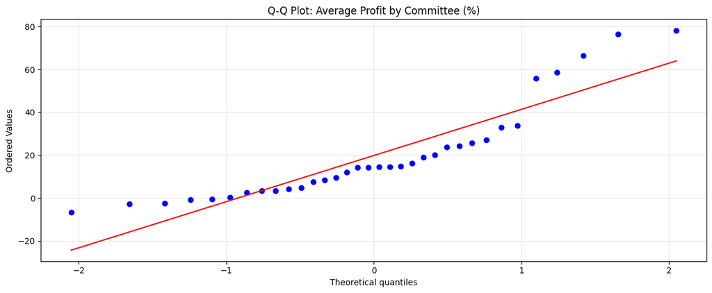

Shapiro-Wilk Test For Normality

| Metric | Value |
| --- | --- |
| Statistic | 0.839409 |
| P-value | 0.000164 |
| Significance | Not Normal |

```python
# annualized trades
stat_com, p_com = shapiro(committee_stats["avg_profit_pct"])

#  Q-Q plots
fig, ax1 = plt.subplots(1, figsize=(12, 5))

stats.probplot(committee_stats["avg_profit_pct"], dist="norm", plot=ax1)
ax1.set_title('Q-Q Plot: Average Profit by Committee (%)')
ax1.grid(alpha=0.3)

plt.tight_layout()
plt.show()

shapiros_table_com = pd.DataFrame({
    'Metric': [
        'Statistic',
        'P-value',
        'Significance',
    ],
    'Value': [
        stat_com,
        p_com,
        'Not Normal' if p_t < 0.05 else 'Normal',
    ]
})

display(HTML('<h3>Shapiro-Wilk Test For Normality</h3>'))
display(shapiros_table_com.style.hide(axis='index'))
```

**Figure 11: Q-Q Plot for Committee Level Trades**  
**Table 13: Shapiro-Wilk results for Committee Level Trades**

Figure 11 shows that the average profit by committees appears roughly normal until theoretical quantiles 1-2 where the data deviates from the normal line more extremely. These 5 extreme data points could indicate the 5 highest performing committees that all beat the market benchmark by over 30%. The Shapiro-Wilk test confirms that the trades by committee are not normally distributed at a significance level of $\alpha = 0.05$ and a p-value of 0.000164.

```python
com_returns = committee_stats["avg_profit_pct"].values
stat_wilcox, p_wilcox = stats.wilcoxon(com_returns - sandp_cagr, alternative='greater')

# Effect Size: Hodges-Lehmann Estimator (non-parametric median difference)
diff = com_returns - sandp_cagr
median_excess = np.median(diff)
mean_excess = np.mean(diff)
std_excess = np.std(diff)

# Rank-biserial correlation (effect size for Wilcoxon)
n = len(com_returns)
r = 1 - (2*stat_wilcox) / (n*(n+1)/2)  # Effect size

# Create DataFrame for Trade-Level Analysis
committee_analysis_df = pd.DataFrame({
    'Metric': [
        'Num Committees',
        'Sample size (trades)',
        'S&P 500 benchmark (%)',
        'Mean excess return (%)',
        'Median excess return (%)',
        'Excess return volatility (%)',
        'Wilcoxon test statistic',
        'P-value',
        'Significance',
        'Effect size (rank-biserial r)',
        'Interpretation'
    ],
    'Value': [
        f"{n}",
        f"{len(trades_with_committees)}",
        f"{(sandp_cagr).item():.2f}",
        f"{mean_excess:.2f}",
        f"{median_excess:.2f}",
        f"{std_excess:.2f}",
        f"{stat_wilcox:.2f}",
        f"{p_wilcox:.6f}",
        '***' if p_wilcox < 0.001 else '**' if p_wilcox < 0.01 else '*' if p_wilcox < 0.05 else 'ns',
        f"{r:.4f}",
        'Small' if abs(r) < 0.3 else 'Medium' if abs(r) < 0.5 else 'Large'
    ]
})

display(HTML('<h3>Committee Analysis (Wilcoxon Signed-Rank Test)</h3>'))
display(committee_analysis_df.style.hide(axis='index'))
```

Committee Analysis (Wilcoxon Signed-Rank Test)

| Metric | Value |
| --- | --- |
| Num Committees | 34 |
| Sample size (trades) | 2202 |
| S&P 500 benchmark (%) | 12.49 |
| Mean excess return (%) | 7.34 |
| Median excess return (%) | 1.94 |
| Excess return volatility (%) | 22.32 |
| Wilcoxon test statistic | 352.00 |
| P-value | 0.175726 |
| Significance | ns |
| Effect size (rank-biserial r) | -0.1832 |
| Interpretation | Small |

**Table 14:**

Table 14 shows the results of a Wilcoxon-Signed rank test on the excess returns by committee to be not significant at $\alpha = 0.05$ with a p-value of 0.176. With 34 committees considered, and 2,202 trades between them, the committees only had an mean excess return of 7.34%. These returns are more recent as these are actively serving Members and their current committee assignments (as of November 2025). While Table 12 indicated that high committee returns could indicate significance, we still observed that about half the committees failed to beat the benchmark. Furthermore, Table 14 shows the volatility is 22.32%. This suggests a wide range of success with top performers seeing outstanding gains while others underperform.

```python
def skew_kurt_graphs(top_excess, title):
    # Calculate statistics (work in decimal, convert to % for display)
    committee_mean = np.mean(top_excess)
    committee_median = np.median(top_excess)
    committee_std = np.std(top_excess, ddof=1)  # ADD - needed for normal curve
    committee_skew = skew(top_excess)
    committee_kurt = kurtosis(top_excess, fisher=False)

    fig, (ax1, ax2) = plt.subplots(1, 2, figsize=(16, 6))

    # LEFT: Zoom into center (±50%)
    center_mask = np.abs(top_excess) <= 0.5
    ax1.hist(top_excess[center_mask], color="lightblue", bins=50, edgecolor='black', alpha=0.7, density=True)

    # Overlay normal - USE STD DEV, not skewness!
    x = np.linspace(-0.5, 0.5, 100)
    normal_curve = norm.pdf(x, committee_mean, committee_std)  # FIXED
    ax1.plot(x, normal_curve, 'r-', linewidth=2, label='Normal')

    ax1.axvline(committee_mean, color='#E67E22', linestyle='--', linewidth=2.5,
                label=f'Mean: {committee_mean*100:.1f}%')  # FIXED - multiply here
    ax1.axvline(committee_median, color='#9B59B6', linestyle='--', linewidth=2.5,
                label=f'Median: {committee_median*100:.1f}%')  # FIXED - multiply here
    ax1.set_xlabel('Excess Return')
    ax1.set_ylabel('Density')
    ax1.set_title(f'Center: {center_mask.sum()} trades ({center_mask.sum()/len(top_excess)*100:.1f}%)')  # FIXED - *100 for %
    ax1.legend()
    ax1.grid(alpha=0.3)

    # RIGHT: Box plot showing outliers
    ax2.boxplot(top_excess * 100, vert=False)  # FIXED - multiply for % display
    ax2.set_xlabel('Excess Return (%)')
    ax2.set_title(f'{title}\nBox Plot: Outliers Visible\nKurtosis = {committee_kurt:.1f} >> 3 (Heavy Tails)')  # FIXED - removed .item()
    ax2.grid(alpha=0.3)
    ax2.axvline(0, color='red', linestyle='--', alpha=0.5, label='Market Performance')
    ax2.legend()

    plt.suptitle(f'Fat Tails: {(~center_mask).sum()} extreme outliers ({(~center_mask).sum()/len(top_excess)*100:.1f}%) drive kurtosis from 3 → {committee_kurt:.1f}\nSkewness: {committee_skew:.2f}',
                fontsize=14, fontweight='bold')
    plt.tight_layout()
    plt.show()
    fig, (ax1, ax2) = plt.subplots(1, 2, figsize=(14, 6))

    # Linear scale
    ax1.hist(top_excess * 100, bins=100, color="lightblue", edgecolor='black', alpha=0.7)
    ax1.axvline(committee_mean * 100, color='crimson', linestyle='--', label=f'Mean: {committee_mean*100:.1f}%')
    ax1.axvline(committee_median * 100, color='darkgreen', linestyle='--', label=f'Median: {committee_median*100:.1f}%')
    ax1.set_xlabel('Excess Return (%)')
    ax1.set_ylabel('Frequency')
    ax1.set_title('Linear Scale')
    ax1.legend()
    ax1.grid(alpha=0.3)

    # LOG scale - makes rare outliers visible
    ax2.hist(top_excess * 100, color="lightblue", bins=100, edgecolor='black', alpha=0.7)
    ax2.set_yscale('log')
    ax2.axvline(committee_mean * 100, color='crimson', linestyle='--', label=f'Mean: {committee_mean*100:.1f}%')
    ax2.axvline(committee_median * 100, color='darkgreen', linestyle='--', label=f'Median: {committee_median*100:.1f}%')
    ax2.set_xlabel('Excess Return (%)')
    ax2.set_ylabel('Frequency (LOG scale)')
    ax2.set_title('Log Scale')
    ax2.legend()
    ax2.grid(alpha=0.3)

    plt.suptitle(f'Skewness = {(committee_skew).item():.1f}, Kurtosis = {(committee_kurt).item():.1f} (EXTREME fat tails)', fontsize=14)
    plt.tight_layout()
    plt.show()
```

Additionally, top influential committees can be analyzed to see if those perceived to have access to more actionable information do produce significant excess returns. These committees were referenced by Ahmed Tahoun in his 2013 paper "The role of stock ownership by US members of Congress on the market for political favors" <sup>[5]</sup>, as well as from OpenSecrets <sup>[9]</sup>.

Tahoun Top 20 Committee Analysis (Wilcoxon Signed-Rank Test)

| Metric | Value |
| --- | --- |
| Num Committees | 20 |
| Sample size (trades) | 2177 |
| S&P 500 benchmark (%) | 12.49 |
| Mean excess return (%) | 12.21 |
| Median excess return (%) | -3.12 |
| Excess return volatility (%) | 96.64 |
| Wilcoxon test statistic | 1135336.00 |
| P-value | 0.955994 |
| Significance | ns |
| Effect size (rank-biserial r) | 0.0422 |
| Interpretation | Small |

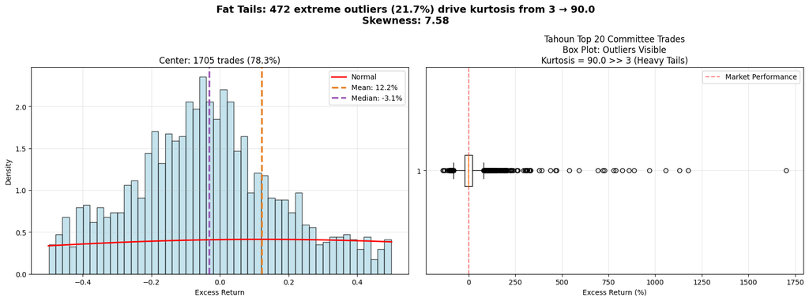

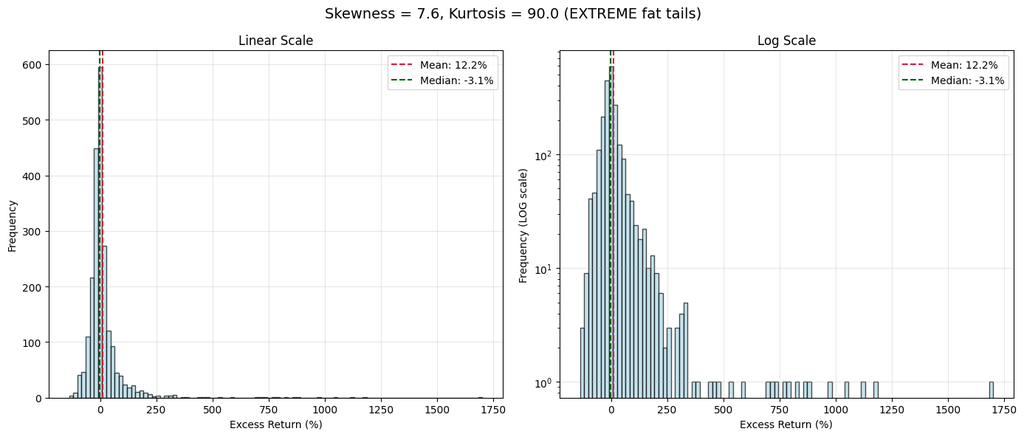

OpenSecrets Top 20 Committee Analysis (Wilcoxon Signed-Rank Test)

| Metric | Value |
| --- | --- |
| Num Committees | 20 |
| Sample size (trades) | 2199 |
| S&P 500 benchmark (%) | 12.49 |
| Mean excess return (%) | 11.88 |
| Median excess return (%) | -3.25 |
| Excess return volatility (%) | 96.25 |
| Wilcoxon test statistic | 1150895.00 |
| P-value | 0.975373 |
| Significance | ns |
| Effect size (rank-biserial r) | 0.0484 |
| Interpretation | Small |

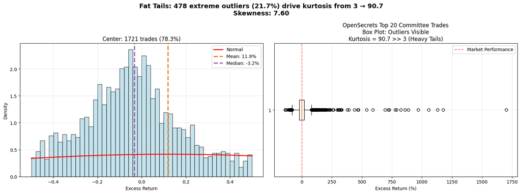

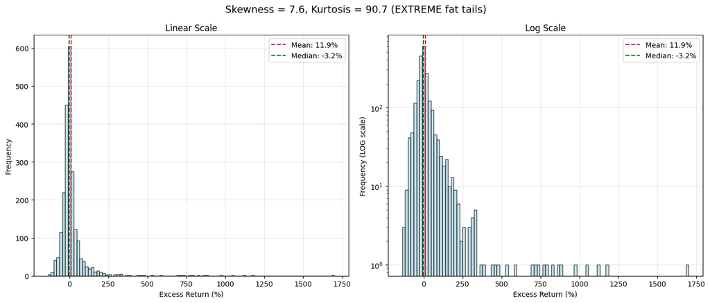

```python
committees_tahoun = ["Senate Committee on Finance",
                     "Senate Committee on Veterans' Affairs",
                     "Senate Committee on Appropriations",
                     "Senate Committee on Rules and Administration",
                     "Senate Committee on Armed Services",
                     "Senate Committee on Foreign Relations",
                     "Senate Select Committee on Intelligence",
                     "Senate Committee on the Judiciary",
                     "Senate Committee on the Budget",
                     "Senate Committee on Commerce, Science, and Transportation",
                     "House Committee on Ways and Means",
                     "House Committee on Appropriations",
                     "House Committee on Energy and Commerce",
                     "House Committee on Rules",
                     "House Committee on Foreign Affairs",
                     "House Committee on Armed Services",
                     "House Permanent Select Committee on Intelligence",
                     "House Committee on the Judiciary",
                     "House Committee on Homeland Security",
                     "House Committee on Transportation and Infrastructure"]

committees_opensecrets = ["Senate Committee on Finance",
                          "Senate Committee on Appropriations",
                          "Senate Committee on the Judiciary",
                          "Senate Committee on Armed Services",
                          "Senate Committee on Commerce, Science, and Transportation",
                          "Senate Committee on Homeland Security and Governmental Affairs",
                          "Senate Committee on Energy and Natural Resources",
                          "Senate Committee on Health, Education, Labor, and Pensions",
                          "Senate Committee on Foreign Relations",
                          "Senate Committee on Agriculture, Nutrition, and Forestry",
                          "House Committee on Appropriations",
                          "House Committee on Ways and Means",
                          "House Committee on Appropriations",
                          "House Committee on Energy and Commerce",
                          "House Committee on Armed Services",
                          "House Committee on the Judiciary",
                          "House Committee on Oversight and Government Reform",
                          "House Committee on Financial Services",
                          "House Committee on Education and Workforce",
                          "House Committee on Science, Space, and Technology"
                          ]

for committee_list in [committees_tahoun, committees_opensecrets]:
    pattern = '|'.join(committee_list)

    # Identify senators who sit on ANY top committee
    top_committee_senators = returns_df[
        returns_df["committees"].str.contains(pattern, case=False, na=False, regex=True)
    ]['owner_name'].unique()

    # Get all trades by those senators (each trade counted ONCE)
    top_committee_trades = returns_df[
        returns_df['owner_name'].isin(top_committee_senators)
    ]

    top_excess = top_committee_trades['excess_return'].values
    top_stat_wilcox, top_p_wilcox = stats.wilcoxon(top_excess, alternative='greater')

    median_excess = np.median(top_excess)
    mean_excess = np.mean(top_excess)
    std_excess = np.std(top_excess)

    n_1 = len(top_excess)
    r = 1 - (2 * top_stat_wilcox) / (n_1 * (n_1 + 1) / 2)

    n_trades = len(top_committee_trades)

    # Create DataFrame for Trade-Level Analysis
    committee_analysis_df = pd.DataFrame({
        'Metric': [
            'Num Committees',
            'Sample size (trades)',
            'S&P 500 benchmark (%)',
            'Mean excess return (%)',
            'Median excess return (%)',
            'Excess return volatility (%)',
            'Wilcoxon test statistic',
            'P-value',
            'Significance',
            'Effect size (rank-biserial r)',
            'Interpretation'
        ],
        'Value': [
            f"{len(committee_list)}",
            f"{n_trades}",
            f"{(sandp_cagr).item():.2f}",
            f"{mean_excess*100:.2f}",
            f"{median_excess*100:.2f}",
            f"{std_excess*100:.2f}",
            f"{top_stat_wilcox:.2f}",
            f"{top_p_wilcox:.6f}",
            '***' if top_p_wilcox < 0.001 else '**' if top_p_wilcox < 0.01 else '*' if top_p_wilcox < 0.05 else 'ns',
            f"{r:.4f}",
            'Small' if abs(r) < 0.3 else 'Medium' if abs(r) < 0.5 else 'Large'
        ]
    })

    display(HTML(f'<h3>{"Tahoun" if committee_list == committees_tahoun else "OpenSecrets"} Top 20 Committee Analysis (Wilcoxon Signed-Rank Test)</h3>'))
    display(committee_analysis_df.style.hide(axis='index'))

    skew_kurt_graphs(top_excess, f'{"Tahoun" if committee_list == committees_tahoun else "OpenSecrets"} Top 20 Committee Trades')
```

**Table 15: Top 20 committees identified by Tahoun, summary statistics and significance**  
**Figure 12: Skew and Kurtosis of Tahoun top 20 committee excess returns, histogram of distribution and box plot of outliers. Histogram is centered about $\pm 50$ percentage points**  
**Figure 13: Linear and Log Scale of Tahoun top 20 committees excess return histograms**  
**Table 16: Top 20 committees identified by OpenSecrets, summary statistics and significance**  
**Figure 14: Skew and Kurtosis of OpenSecrets top 20 committee excess returns, histogram of distribution and box plot of outliers. Histogram is centered about $\pm 50$ percentage points**  
**Figure 15: Linear and Log Scale of OpenSecrets top 20 committees excess return histograms**

For reference, top 20 committees are:

- Tahoun 2012: ["Senate Committee on Finance", "Senate Committee on Veterans' Affairs", "Senate Committee on Appropriations", "Senate Committee on Rules and Administration", "Senate Committee on Armed Services", "Senate Committee on Foreign Relations", "Senate Select Committee on Intelligence", "Senate Committee on the Judiciary", "Senate Committee on the Budget", "Senate Committee on Commerce, Science, and Transportation", "House Committee on Ways and Means", "House Committee on Appropriations", "House Committee on Energy and Commerce", "House Committee on Rules", "House Committee on Foreign Affairs", "House Committee on Armed Services", "House Permanent Select Committee on Intelligence", "House Committee on the Judiciary", "House Committee on Homeland Security", "House Committee on Transportation and Infrastructure"]
- OpenSecrets: ["Senate Committee on Finance", "Senate Committee on Appropriations", "Senate Committee on the Judiciary", "Senate Committee on Armed Services", "Senate Committee on Commerce, Science, and Transportation", "Senate Committee on Homeland Security and Governmental Affairs", "Senate Committee on Energy and Natural Resources", "Senate Committee on Health, Education, Labor, and Pensions", "Senate Committee on Foreign Relations", "Senate Committee on Agriculture, Nutrition, and Forestry", "House Committee on Appropriations", "House Committee on Ways and Means", "House Committee on Appropriations", "House Committee on Energy and Commerce", "House Committee on Armed Services", "House Committee on the Judiciary", "House Committee on Oversight and Government Reform", "House Committee on Financial Services", "House Committee on Education and Workforce", "House Committee on Science, Space, and Technology"]

*Note: some committees were invalid as they have changed names, or have no active members (in the dataset) so those were substituted for the next committee. Ex. If the House committee on rules is ranked 10, but is invalid, number 11 House Committee on Foreign Affairs would take the number 10 spot.

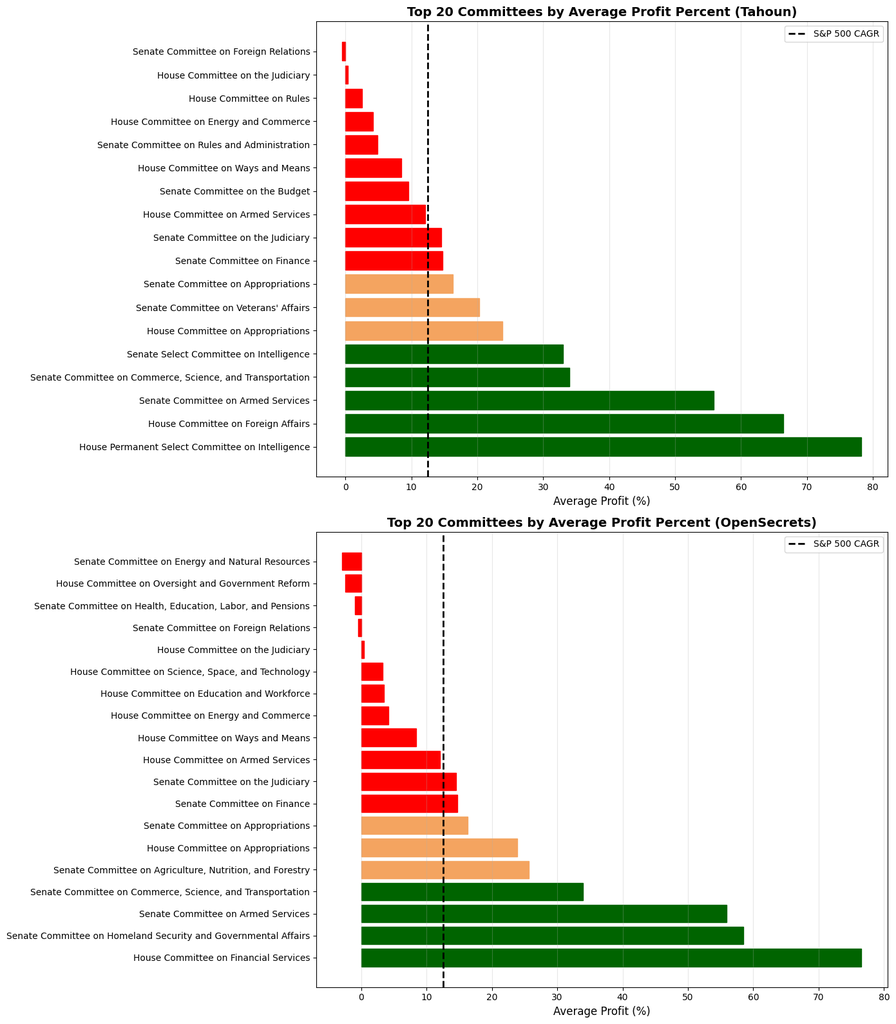

```python
fig, (ax1, ax2) = plt.subplots(2, 1, figsize=(14, 16))

top_20_tahoun = committee_stats[committee_stats.index.isin(committees_tahoun)]
top_20_opensecrets = committee_stats[committee_stats.index.isin(committees_opensecrets)]

# Plot 1: Top 20 Tahoun
bars1 = ax1.barh(range(len(top_20_tahoun)), top_20_tahoun['avg_profit_pct'], color='steelblue')

# Add benchmark line
ax1.axvline(x=12.5, color='black', linestyle='--', linewidth=2, label='S&P 500 CAGR')

# Color bars based on performance
for i, bar in enumerate(bars1):
    value = top_20_tahoun.iloc[i]['avg_profit_pct']
    if value > 30:
        bar.set_color('darkgreen')
    elif value > 15:
        bar.set_color('sandybrown')
    else:
        bar.set_color('red')

ax1.set_yticks(range(len(top_20_tahoun)))
ax1.set_yticklabels(top_20_tahoun.index, fontsize=10)
ax1.set_xlabel('Average Profit (%)', fontsize=12)
ax1.set_title('Top 20 Committees by Average Profit Percent (Tahoun)', fontsize=14, fontweight='bold')
ax1.legend()
ax1.grid(axis='x', alpha=0.3)

# Plot 2: Top 20 OpenSecrets
bars2 = ax2.barh(range(len(top_20_opensecrets)), top_20_opensecrets['avg_profit_pct'], color='steelblue')

# Add benchmark line
ax2.axvline(x=12.5, color='black', linestyle='--', linewidth=2, label='S&P 500 CAGR')

# Color bars based on performance
for i, bar in enumerate(bars2):
    value = top_20_opensecrets.iloc[i]['avg_profit_pct']
    if value > 30:
        bar.set_color('darkgreen')
    elif value > 15:
        bar.set_color('sandybrown')
    else:
        bar.set_color('red')

ax2.set_yticks(range(len(top_20_opensecrets)))
ax2.set_yticklabels(top_20_opensecrets.index, fontsize=10)
ax2.set_xlabel('Average Profit (%)', fontsize=12)
ax2.set_title('Top 20 Committees by Average Profit Percent (OpenSecrets)', fontsize=14, fontweight='bold')
ax2.legend()
ax2.grid(axis='x', alpha=0.3)

plt.tight_layout()
plt.show()
```

**Figure 16: Bar chart for Tahoun top 20 committees**  
**Figure 17: Bar chart for OpenSecrets top 20 committees**

Figures 16 and 17 show that 8 of Tahoun's committees, and 10 from OpenSecrets fail to beat the market benchmark. While the best performers in Table 12 looked strong, we can observe that without cherry-picking those best performers, poorly performing committees balance out those who trade exceptionally well. This reinforces the consistent pattern we have seen throughout the data, that some trades, Members, and committees do beat the market by a considerable amount, average and underperfoming positions balance the outliers, resulting in overall insignificant returns.

### Conclusion and Next Steps

This study assessed whether 12 years of data following the STOCK Act could provide insight into claims of Congressional Members exploiting informational advantages for personal gain. Building on related prior research as well numerous articles and examples detailing evidence of suspicious trading activity, access to new and post-pandemic data has allowed for an updated analysis of the subject. The accusations, examples, and initial visualizations of top performers indicated possible wrongdoing, supported by statistical significance when comparing all congressional trades against S&P 500 market benchmarks. However, further analysis of annualized returns, Member specific portfolios, and examination of influential committee membership all provided insignificant results. Despite these overall findings, a noticeable and consistent trend appeared in almost every analysis. While many returns appear consistent with fair trading practices being near, or considerably worse than the market benchmark, a group of outliers saw substantial abnormal gains. This was apparent in the insignificant annualized returns, Member portfolios, distributions of returns, and committee performances. This smaller group of Members, committees, and trades were typically short term, high-returns that when set aside would beat the market by such large margins it would severely effect the rest of the data. These outliers are not enough to conclude wrongdoing, and more rigorous statistical testing would need to be implemented in order to investigate further. It does appear that most Members, whether or not they are given access to information to benefit upon, act in good faith, with some even seeing substantial losses. The outliers who consistently beat the market, and see gains far beyond those of top performing financial professionals, while also taking on considerably less risk, stand out due to the outstanding nature of their success. The question of additional legislation restricting congressional trading remains relevant, particularly given equity concerns when some Members achieve such exceptional returns.

If this research were to continue, it would be beneficial to tweak and expand on current tests, introduce more robust methods, non-static market metrics for certain significance tests, and test for significance in those groups of extreme outliers. Previous research also used a Carhart 4-factor model, which could be used to evaluate Member performance, but might be more difficult to implement. Further, exploration using machine learning to determine if stock performance can be predicted based on Member interest, or a collection of additional data on trades, Member portfolios, and active and past committee membership could strengthen the analysis and provide additional insight.

```python
# import statsmodels.api as sm
# could do carhart alpha next
# # 1. Download Fama-French factors from:
# # https://mba.tuck.dartmouth.edu/pages/faculty/ken.french/data_library.html

# ff_factors = pd.read_csv('F-F_Research_Data_Factors.csv')
# momentum = pd.read_csv('F-F_Momentum_Factor.csv')

# # 2. Merge with your portfolio returns
# # Need monthly portfolio returns aligned with factor dates

# X = ff_factors[['Mkt-RF', 'SMB', 'HML']]
# X['MOM'] = momentum['Mom']
# X = sm.add_constant(X)

# y = portfolio_excess_returns

# model = sm.OLS(y, X).fit()
# alpha = model.params['const']  #carhart alpha
# print(model.summary())
```

### References

[1] Admin, “Ban on stock trading for members of Congress favored by overwhelming bipartisan majority,” publicconsultation.org, https://publicconsultation.org/united-states/stock-trading-by-members-of-congress/.  
[2]“Congressional stock trading, explained,” Brennan Center for Justice, https://www.brennancenter.org/our-work/research-reports/congressional-stock-trading-explained.  
[3]S.2038 - 112th Congress (2011-2012): Stock act | congress.gov | library of Congress, https://www.congress.gov/bill/112th-congress/senate-bill/2038.  
[4]R. Huang and Y. Xuan, “‘Trading’ Political Favors: Evidence from the impact of the Stock Act*,” SSRN Electronic Journal, https://business.gwu.edu/sites/g/files/zaxdzs5326/files/HuangXuan_STOCKAct.pdf.  
[5]A. Tahoun, “The role of stock ownership by US members of Congress on the market for political favors - sciencedirect,” ScienceDirect, https://www.sciencedirect.com/science/article/abs/pii/S0304405X13002705.  
[6]N. Reiff, “Why do investors use the S&P 500 as a benchmark?,” Investopedia, https://www.investopedia.com/ask/answers/041315/what-are-pros-and-cons-using-sp-500-benchmark.asp.  
[7]“Decoding the average hedge fund return,” Hedge Fund Alpha, https://hedgefundalpha.com/education/average-hedge-fund-return/.  
[8]J. B. Maverick, “What the Sharpe ratio means for investors,” Investopedia, https://www.investopedia.com/ask/answers/010815/what-good-sharpe-ratio.asp#:~:text=Any%20Sharpe%20ratio%20greater%20than,1.0%20is%20considered%20sub%2Doptimal.  
[9]“Top congressional committees • opensecrets,” OpenSecrets, https://www.opensecrets.org/revolving-door/congressional-committees?chamber=H.